# Slides - Prosper Loan Data Analysis

## by Progress Akpelu

## Investigation Overview

> In this analysis, i wanted to look at the factors a loan company, the Proper loan considers before individuals can get a loan and how these factors could be used to predict the interest rate and annual APR of the borrower..

## Dataset Overview

> This data set contains 113,937 loans with 81 variables on each loan, including loan amount, borrower rate (or interest rate), current loan status, borrower income, and many others..

## Distribution of Borrower Rate

Interest rate for most of the borrowers were quite high. More than 7000 borrowers paid high interest rate of 0.32, also know as BorrowerRate. With less 1000 borrowers paying interest rate less than 0.05.

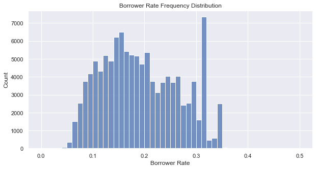

## Distribution of Borrower APR

The Borrower APR for most borrowers were high. More borrowers paid more annual percentage rate. More than 7000 borrowers had their APR at 0.36. Which showed that most peersons who got the loan accounted for high APR.

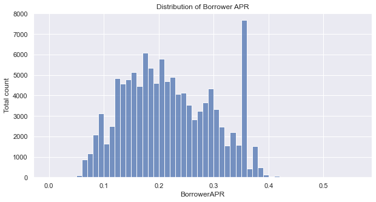

[figure not shown]

The Prosper rating (1 - HR, 2 - E, 3 - D, 4 - C, 5 - B, 6 - A, 7 - AA) of the borrower accounts for how much interest is paid. Higher rating means low interest rate and low rating means high interest rate. For a borrower to obtain loan with low interest rate, the borrower must get a good rating which are also determined by factors such as Employment status, if the borrower has a home and the monthly income.

[figure not shown]

## ProsperScore vs BorrowerRate vs IsBorrowerHomeowner

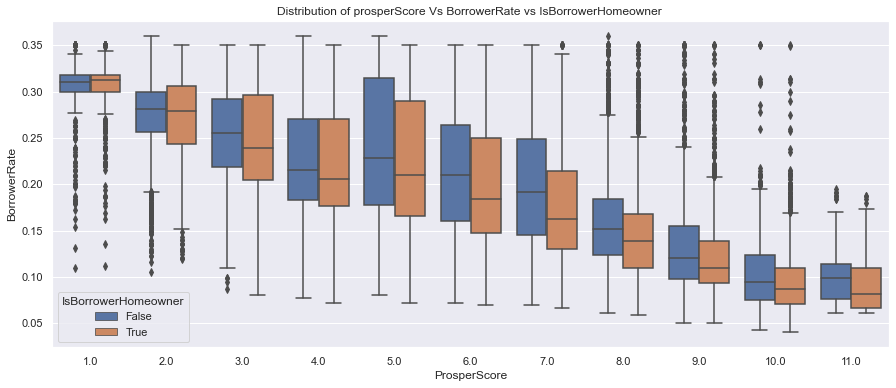